```python
# -*- coding: utf-8 -*-
```

Created on Tue Jun 2 11:06:39 2020  
author: jaketuricchi Generated in Spyder 4.0 using J2P for conversion from .py to .ipynb

# Predicting the final EPL table:

Using a machine learning model generated on game-level data and VAR forecasting

Aim 1: We want to predict match reuslt given match statistics (removing obvious stats such as goals); Supervised classification

Aim 2: Forecast match features for the final 6 games of the season using VAR

Aim 3: Predict the last 6 results for each team using the previously generated model.

Aim 4: Predict final league table (ML/forecasting?)

All meanings of variables can be found at: https://www.kaggle.com/idoyo92/epl-stats-20192020 along with the complete data set.

% Import packages

```python
import math
import pandas as pd
import numpy as np
import os
import matplotlib.pyplot as plt
import warnings
import seaborn as sns
import sklearn
from datetime import datetime
import calendar
%matplotlib inline
import shelve
import warnings
warnings.simplefilter('ignore')
```

Set wd and read in data

```python
os.chdir(r"C:/Users/jaket/Dropbox/Kaggle/EPL_prediction")
```

```python
games = pd.read_csv('epl2020.csv')
```

# Sort games df

```python
print(games.columns)
print(games.isna().sum()) #no missing data
```

```
Index(['Unnamed: 0', 'h_a', 'xG', 'xGA', 'npxG', 'npxGA', 'deep',
       'deep_allowed', 'scored', 'missed', 'xpts', 'result', 'date', 'wins',
       'draws', 'loses', 'pts', 'npxGD', 'teamId', 'ppda_cal', 'allowed_ppda',
       'matchtime', 'tot_points', 'round', 'tot_goal', 'tot_con', 'Referee.x',
       'HS.x', 'HST.x', 'HF.x', 'HC.x', 'HY.x', 'HR.x', 'AS.x', 'AST.x',
       'AF.x', 'AC.x', 'AY.x', 'AR.x', 'B365H.x', 'B365D.x', 'B365A.x',
       'HtrgPerc', 'AtrgPerc', 'matchDay'],
      dtype='object')
Unnamed: 0      0
h_a             0
xG              0
xGA             0
npxG            0
npxGA           0
deep            0
deep_allowed    0
scored          0
missed          0
xpts            0
result          0
date            0
wins            0
draws           0
loses           0
pts             0
npxGD           0
teamId          0
ppda_cal        0
allowed_ppda    0
matchtime       0
tot_points      0
round           0
tot_goal        0
tot_con         0
Referee.x       0
HS.x            0
HST.x           0
HF.x            0
HC.x            0
HY.x            0
HR.x            0
AS.x            0
AST.x           0
AF.x            0
AC.x            0
AY.x            0
AR.x            0
B365H.x         0
B365D.x         0
B365A.x         0
HtrgPerc        0
AtrgPerc        0
matchDay        0
dtype: int64
```

```python
games = games.drop('Unnamed: 0', axis=1) # drop useless column
games = games.drop(['scored', 'missed', 'wins', 'draws', 'loses', 'pts',
                    'tot_points', 'tot_goal', 'tot_con'], axis=1) # drop columns which give away result
```

Code target

```python
games['target']=np.where(games['result']=='l', 0,
                         np.where(games['result']=='d', 1,2))
```

Drop result string variable

```python
games = games.drop('result', axis=1) # drop useless column
```

Set categorical variables

```python
games[['target', 'h_a', 'teamId', 'Referee.x', 'matchDay']] = games[['target', 'h_a', 'teamId', 'Referee.x', 'matchDay']].astype('category')
```

# EDA

Here we explore 'expected' variables (goals, concedes) given by the bookmakers, in relation to the target. We could do a more extensive visualisation with more time.

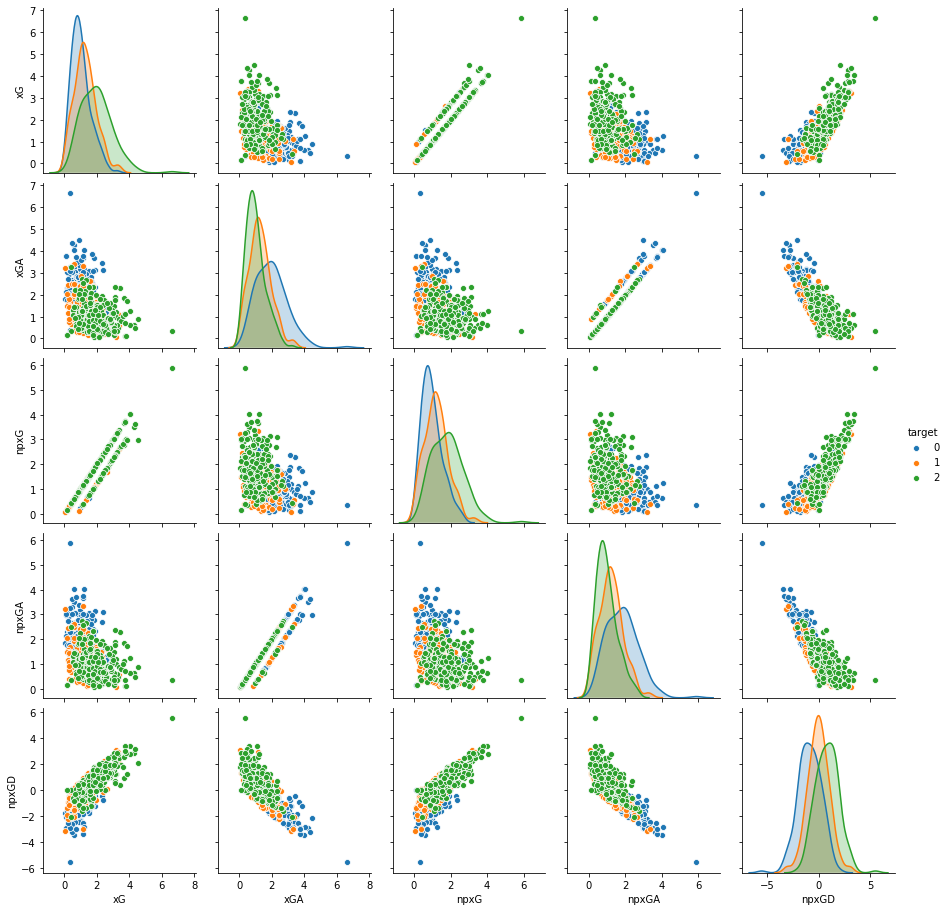

```python
EDA_pairplot1=games.filter(items=['xG', 'xGA', 'npxG', 'npxGA', 'npxGD', 'h_a', 'target'])
sns.pairplot(EDA_pairplot1, hue='target')
```

Here we explore HOME team match stats, in relation to the target

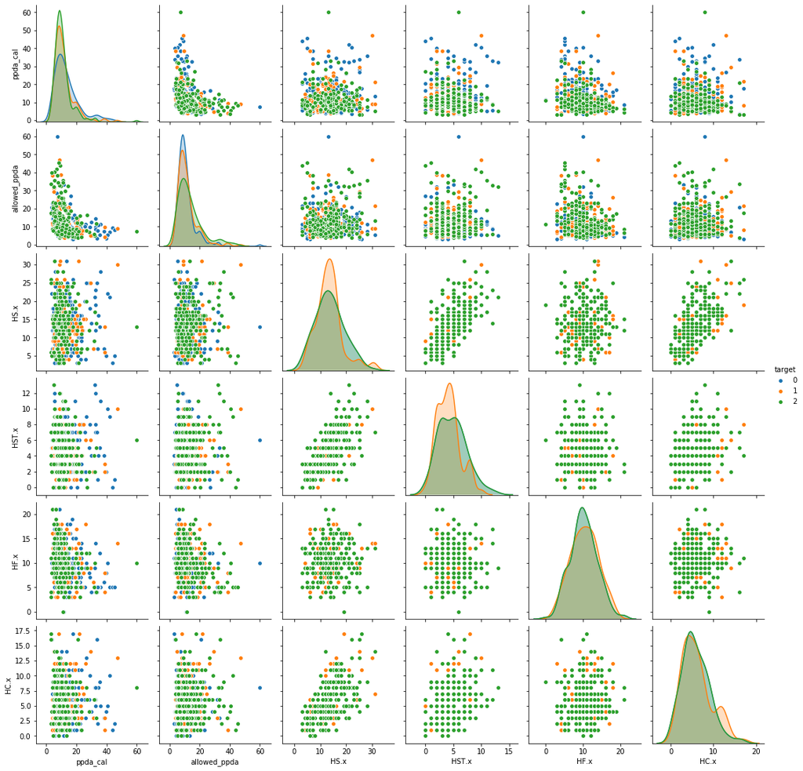

```python
EDA_pairplot2=games.filter(items=['ppda_cal', 'allowed_ppda', 'HS.x', 'HST.x', 'HF.x', 'HC.x', 'target'])
sns.pairplot(EDA_pairplot2, hue='target')
```

Here we explore AWAY team match stats, in relation to the target

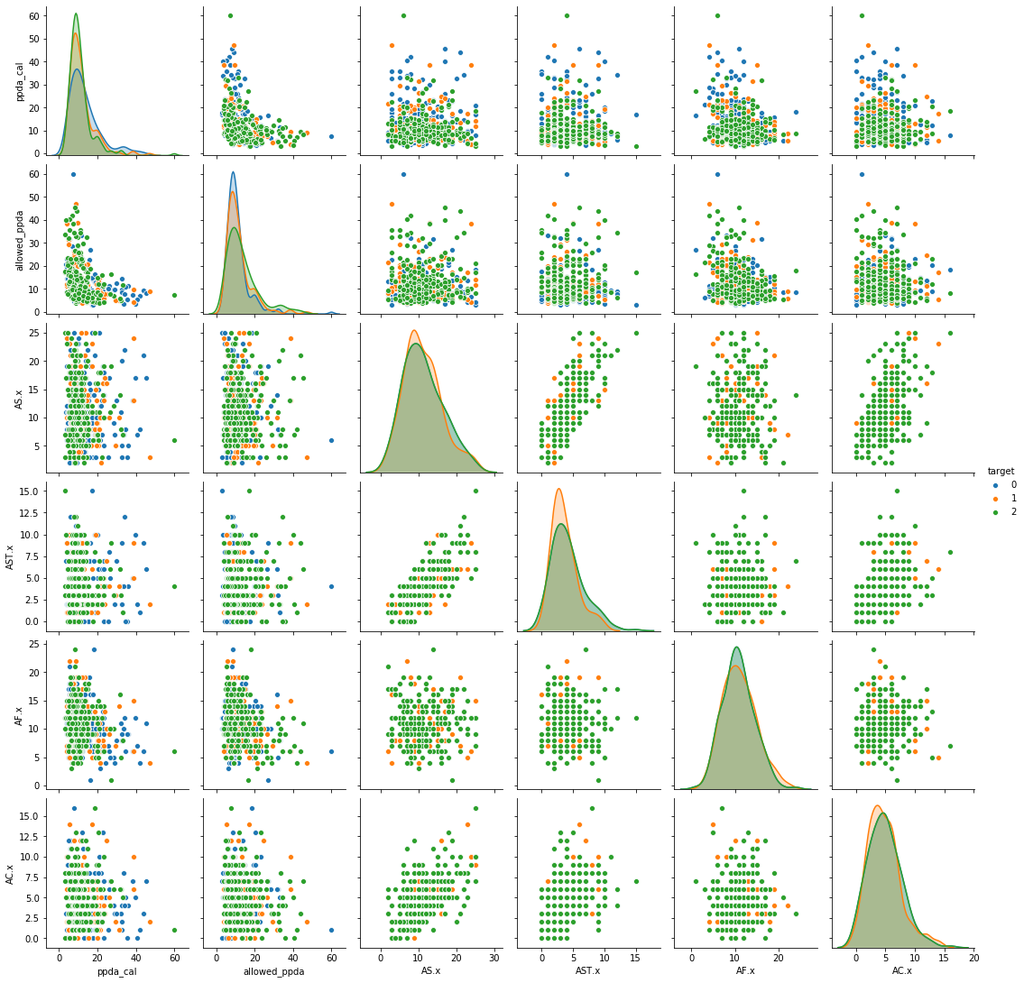

```python
EDA_pairplot3=games.filter(items=['ppda_cal', 'allowed_ppda', 'AS.x', 'AST.x', 'AF.x', 'AC.x', 'target'])
sns.pairplot(EDA_pairplot3, hue='target')
```

Game outcomes

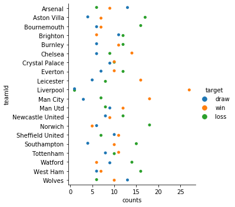

```python
EDA_plot4=games.groupby('teamId')['target'].agg(counts='value_counts').reset_index()
EDA_plot4['target']=np.where(EDA_plot4['target']==0, 'loss',
                         np.where(EDA_plot4['target']==1, 'draw','win'))
EDA_plot4=EDA_plot4.reset_index()
sns.catplot(y="teamId",x='counts', hue='target',data=EDA_plot4)
```

# Modelling - Preprocessing

Scale numeric data

```python
from sklearn.preprocessing import StandardScaler
```

```python
nums= games.select_dtypes(include=['float', 'int64'])
other= games.select_dtypes(exclude=['float', 'int64']).drop(['date', 'target'], axis=1)
```

```python
scaler = StandardScaler()
nums_scaled = scaler.fit_transform(nums)
games_scaled=pd.DataFrame(nums_scaled, columns=nums.columns)
```

One hot encode categorical data

```python
dummies=pd.get_dummies(other)
```

Generate an analysis dataset

```python
gameday_pred = pd.concat([games_scaled,dummies, games['target']], axis=1)
```

Split the data into features and labels

```python
X=gameday_pred.drop('target', axis=1)
y=gameday_pred['target']
```

```python
print(y.dtypes)
print(X.dtypes)
```

```
category
xG              float64
xGA             float64
npxG            float64
npxGA           float64
deep            float64
                 ...
matchDay_Sat      uint8
matchDay_Sun      uint8
matchDay_Thu      uint8
matchDay_Tue      uint8
matchDay_Wed      uint8
Length: 80, dtype: object
```

Split the data intro train and test sets for model training

```python
from sklearn.model_selection import train_test_split
X_train, X_test, y_train, y_test = train_test_split(X, y, test_size = 0.3, random_state = 42)
```

# Algorithm testing and initial selection

Load packages

```python
from sklearn.ensemble import RandomForestClassifier, AdaBoostClassifier, GradientBoostingClassifier
from sklearn.naive_bayes import GaussianNB
from sklearn.discriminant_analysis import LinearDiscriminantAnalysis,  QuadraticDiscriminantAnalysis
from sklearn.svm import SVC, LinearSVC, NuSVC
from sklearn.neighbors import KNeighborsClassifier
from sklearn.tree import DecisionTreeClassifier
from sklearn.metrics import confusion_matrix, accuracy_score, log_loss, precision_score, recall_score, f1_score
```

Select classification algorithms we'll test

```python
classifiers = [
    KNeighborsClassifier(3),
    SVC(kernel="rbf", C=0.025, probability=True),
    DecisionTreeClassifier(),
    RandomForestClassifier(),
    AdaBoostClassifier(),
    GradientBoostingClassifier(),
    GaussianNB(),
    LinearDiscriminantAnalysis(),
    QuadraticDiscriminantAnalysis()]
```

Logging for Visual Comparison

```python
log_cols=["Classifier", "Accuracy", "Log Loss"]
log = pd.DataFrame(columns=log_cols)
```

Run algo loop

```python
for clf in classifiers:
    clf.fit(X_train, y_train)
    name = clf.__class__.__name__

    print("="*30)
    print(name)

    print('****Results****')
    train_predictions = clf.predict(X_test)
    acc = accuracy_score(y_test, train_predictions)

    # calculate score
    precision = precision_score(y_test, train_predictions, average = 'macro')
    recall = recall_score(y_test, train_predictions, average = 'macro')
    f_score = f1_score(y_test, train_predictions, average = 'macro')


    print("Precision: {:.4%}".format(precision))
    print("Recall: {:.4%}".format(recall))
    print("F-score: {:.4%}".format(recall))
    print("Accuracy: {:.4%}".format(acc))

    train_predictions = clf.predict_proba(X_test)
    ll = log_loss(y_test, train_predictions)
    print("Log Loss: {}".format(ll))

    log_entry = pd.DataFrame([[name, acc*100, ll]], columns=log_cols)
    log = log.append(log_entry)

print("="*30)
```

```
==============================
KNeighborsClassifier
****Results****
Precision: 52.4607%
Recall: 51.9339%
F-score: 51.9339%
Accuracy: 53.7572%
Log Loss: 9.00414132447046
==============================
SVC
****Results****
Precision: 11.3680%
Recall: 33.3333%
F-score: 33.3333%
Accuracy: 34.1040%
Log Loss: 0.898023417658708
```

```
==============================
DecisionTreeClassifier
****Results****
Precision: 47.0482%
Recall: 47.2198%
F-score: 47.2198%
Accuracy: 47.9769%
Log Loss: 17.968149569606712
==============================
RandomForestClassifier
****Results****
Precision: 56.8903%
Recall: 54.6466%
F-score: 54.6466%
Accuracy: 57.8035%
Log Loss: 0.9000805360820573
==============================
AdaBoostClassifier
****Results****
Precision: 48.8319%
Recall: 49.0785%
F-score: 49.0785%
Accuracy: 50.2890%
Log Loss: 1.0058309491537187
==============================
GradientBoostingClassifier
****Results****
Precision: 66.3919%
Recall: 65.1087%
F-score: 65.1087%
Accuracy: 66.4740%
Log Loss: 0.8145900224252158
==============================
GaussianNB
****Results****
Precision: 54.0435%
Recall: 47.4495%
F-score: 47.4495%
Accuracy: 43.9306%
Log Loss: 10.24718535566878
==============================
LinearDiscriminantAnalysis
****Results****
Precision: 52.4298%
Recall: 52.8177%
F-score: 52.8177%
Accuracy: 56.0694%
Log Loss: 1.143337883226415
==============================
QuadraticDiscriminantAnalysis
****Results****
Precision: 52.6128%
Recall: 50.5249%
F-score: 50.5249%
Accuracy: 47.9769%
Log Loss: 13.853277139045032
==============================
```

collinearity should be expected given the type of data

# Plot results of algo testing

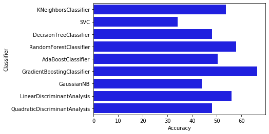

```python
sns.barplot(x='Accuracy', y='Classifier', data=log, color="b")
```

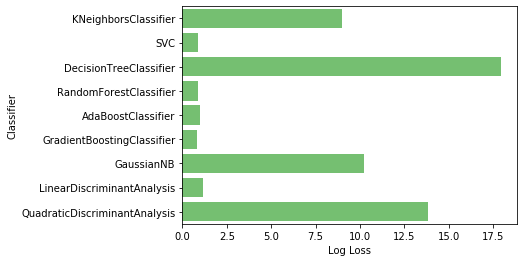

```python
sns.set_color_codes("muted")
sns.barplot(x='Log Loss', y='Classifier', data=log, color="g")
```

What are the most important features?

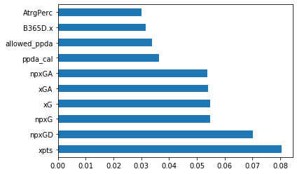

```python
rf = RandomForestClassifier(n_estimators=500)
rf.fit(X_train, y_train);
feat_importances = pd.Series(rf.feature_importances_, index=X_train.columns)
feat_importances.nlargest(10).plot(kind='barh')
```

These results suggest that the 'expected' (i.e. betting agent prediction) variables provide more predictive value than the actual game statistics which is surprising.

# Model selection and tuning

The initial results suggest that XGb and RF are the two best performing classifiers for this problem. Lets begin by tuning the best algorithm (XGb)

```python
from sklearn.model_selection import GridSearchCV
from xgboost import XGBClassifier
import xgboost as xgb
```

```python
xgb = XGBClassifier(objective='multi:softprob',silent=False)
```

Generate a basic Xgb model and predict the test data

```python
xgb.fit(X_train,y_train)
y_pred_xgb_basic=xgb.predict(X_test)
```

```
[13:05:10] WARNING: C:\Users\Administrator\workspace\xgboost-win64_release_1.1.0\src\learner.cc:480:
Parameters: { silent } might not be used.

  This may not be accurate due to some parameters are only used in language bindings but
  passed down to XGBoost core.  Or some parameters are not used but slip through this
  verification. Please open an issue if you find above cases.
```

Calculate score

```python
precision = precision_score(y_test, y_pred_xgb_basic, average = 'macro') * 100
recall = recall_score(y_test, y_pred_xgb_basic, average = 'macro') * 100
f_score = f1_score(y_test, y_pred_xgb_basic, average = 'macro') * 100
a_score = accuracy_score(y_test, y_pred_xgb_basic) * 100
```

```python
print('Precision: %.3f' % precision)
print('Recall: %.3f' % recall)
print('F-Measure: %.3f' % f_score)
print('Accuracy: %.3f' % a_score)
```

```
Precision: 68.232
Recall: 65.625
F-Measure: 66.106
Accuracy: 66.474
```

Tuning the XGb using Grid search

```python
parameters_xgb = {
        'learning_rate': [0.05, 0.1, 0.2, 0.3, 0.5],
        'n_estimators': [200, 300, 400, 500, 600],
        'max_depth': [1, 5, 10, 15, 20],
        'gamma' :[0.1, 0.5, 1, 2, 5],
        'subsample': [0.5, 0.75, 1],
        'colsample_bytree': [0.01, 0.1, 0.5, 1],
        }
```

Instantiate the grid search model

```python
grid_search_xgb = GridSearchCV(estimator = xgb, param_grid = parameters_xgb,
                          cv = 3,n_jobs=-1, verbose = 2)
```

Fit the grid search to the data

```python
grid_search_xgb.fit(X_train,y_train)
print(grid_search_xgb.best_params_)
    # {'colsample_bytree': 0.1, 'gamma': 0.5, 'learning_rate': 0.3, 'max_depth': 15, 'n_estimators': 300, 'subsample': 1}
```

```
Fitting 3 folds for each of 7500 candidates, totalling 22500 fits
```

[output not shown]

```
[14:57:39] WARNING: C:\Users\Administrator\workspace\xgboost-win64_release_1.1.0\src\learner.cc:480:
Parameters: { silent } might not be used.

  This may not be accurate due to some parameters are only used in language bindings but
  passed down to XGBoost core.  Or some parameters are not used but slip through this
  verification. Please open an issue if you find above cases.


{'colsample_bytree': 0.5, 'gamma': 2, 'learning_rate': 0.2, 'max_depth': 10, 'n_estimators': 500, 'subsample': 1}
```

Run best params

```python
best_grid_xgb = grid_search_xgb.best_estimator_
best_grid_xgb.fit(X_train,y_train)
```

```
[14:57:42] WARNING: C:\Users\Administrator\workspace\xgboost-win64_release_1.1.0\src\learner.cc:480:
Parameters: { silent } might not be used.

  This may not be accurate due to some parameters are only used in language bindings but
  passed down to XGBoost core.  Or some parameters are not used but slip through this
  verification. Please open an issue if you find above cases.
```

```
XGBClassifier(base_score=0.5, booster='gbtree', colsample_bylevel=1,
              colsample_bynode=1, colsample_bytree=0.5, gamma=2, gpu_id=-1,
              importance_type='gain', interaction_constraints='',
              learning_rate=0.2, max_delta_step=0, max_depth=10,
              min_child_weight=1, missing=nan, monotone_constraints='()',
              n_estimators=500, n_jobs=0, num_parallel_tree=1,
              objective='multi:softprob', random_state=0, reg_alpha=0,
              reg_lambda=1, scale_pos_weight=None, silent=False, subsample=1,
              tree_method='exact', validate_parameters=1, verbosity=None)
```

Predict test data

```python
y_pred_xgb = best_grid_xgb.predict(X_test)
```

Calculate score

```python
precision = precision_score(y_test, y_pred_xgb, average = 'macro') * 100
recall = recall_score(y_test, y_pred_xgb, average = 'macro') * 100
f_score = f1_score(y_test, y_pred_xgb, average = 'macro') * 100
a_score = accuracy_score(y_test, y_pred_xgb) * 100
```

```python
print('Precision: %.3f' % precision)
print('Recall: %.3f' % recall)
print('F-Measure: %.3f' % f_score)
print('Accuracy: %.3f' % a_score)
```

```
Precision: 69.414
Recall: 65.111
F-Measure: 65.229
Accuracy: 67.630
```

Hyperparameter tuning gives us a very small additional boost in XGB performance. We could improve the grid search but are limited by time and computation power currently.

# Tune random forest

Generate a basic model

```python
rf = RandomForestClassifier(random_state = 1)
rf_model_basic = rf.fit(X_train, y_train)
y_pred_rf_basic = rf_model_basic.predict(X_test)
```

Calculate score

```python
precision = precision_score(y_test, y_pred_rf_basic, average = 'macro') * 100
recall = recall_score(y_test, y_pred_rf_basic, average = 'macro') * 100
f_score = f1_score(y_test, y_pred_rf_basic, average = 'macro') * 100
a_score = accuracy_score(y_test, y_pred_rf_basic) * 100
```

```python
print('Precision: %.3f' % precision)
print('Recall: %.3f' % recall)
print('F-Measure: %.3f' % f_score)
print('Accuracy: %.3f' % a_score)
```

```
Precision: 64.032
Recall: 57.873
F-Measure: 57.786
Accuracy: 60.694
```

Tuning the RF using Grid search

```python
parameters_rf = {
    'bootstrap': [True],
    'n_estimators' : [100, 300, 500, 800, 1200],
    'max_depth' : [5, 8, 15, 25, 30],
    'min_samples_split' : [2, 5, 10, 15, 100],
    'min_samples_leaf' : [1, 2, 5, 10],
    'max_features': [2, 4]
}
```

Instantiate the grid search model

```python
grid_search_rf = GridSearchCV(estimator = rf, param_grid = parameters_rf,
                          cv = 3,n_jobs=-1, verbose = 2)
```

Fit the grid search to the data

```python
grid_search_rf.fit(X_train,y_train)
print(grid_search_rf.best_params_)
    # {'bootstrap': True, 'max_depth': 15, 'max_features': 4, 'min_samples_leaf': 1, 'min_samples_split': 2, 'n_estimators': 800}
```

```
Fitting 3 folds for each of 1000 candidates, totalling 3000 fits
```

```
[Parallel(n_jobs=-1)]: Using backend LokyBackend with 4 concurrent workers.
[Parallel(n_jobs=-1)]: Done  33 tasks      | elapsed:   11.2s
[Parallel(n_jobs=-1)]: Done 154 tasks      | elapsed:   44.6s
[Parallel(n_jobs=-1)]: Done 357 tasks      | elapsed:  1.6min
[Parallel(n_jobs=-1)]: Done 640 tasks      | elapsed:  2.9min
[Parallel(n_jobs=-1)]: Done 1005 tasks      | elapsed:  4.6min
[Parallel(n_jobs=-1)]: Done 1450 tasks      | elapsed:  6.7min
[Parallel(n_jobs=-1)]: Done 1977 tasks      | elapsed:  9.2min
[Parallel(n_jobs=-1)]: Done 2584 tasks      | elapsed: 12.0min
[Parallel(n_jobs=-1)]: Done 3000 out of 3000 | elapsed: 14.1min finished
```

```
{'bootstrap': True, 'max_depth': 15, 'max_features': 4, 'min_samples_leaf': 1, 'min_samples_split': 2, 'n_estimators': 800}
```

Run best params

```python
best_grid_rf = grid_search_rf.best_estimator_
best_grid_rf.fit(X_train,y_train)
```

```
RandomForestClassifier(bootstrap=True, ccp_alpha=0.0, class_weight=None,
                       criterion='gini', max_depth=15, max_features=4,
                       max_leaf_nodes=None, max_samples=None,
                       min_impurity_decrease=0.0, min_impurity_split=None,
                       min_samples_leaf=1, min_samples_split=2,
                       min_weight_fraction_leaf=0.0, n_estimators=800,
                       n_jobs=None, oob_score=False, random_state=1, verbose=0,
                       warm_start=False)
```

Predict test data

```python
y_pred_rf = best_grid_rf.predict(X_test)
```

Calculate score

```python
precision = precision_score(y_test, y_pred_rf, average = 'macro') * 100
recall = recall_score(y_test, y_pred_rf, average = 'macro') * 100
f_score = f1_score(y_test, y_pred_rf, average = 'macro') * 100
a_score = accuracy_score(y_test, y_pred_rf) * 100
```

```python
print('Precision: %.3f' % precision)
print('Recall: %.3f' % recall)
print('F-Measure: %.3f' % f_score)
print('Accuracy: %.3f' % a_score)
```

```
Precision: 66.163
Recall: 60.313
F-Measure: 61.020
Accuracy: 62.428
```

Small increases in performance observed from tuning the RF, but a tuned XGb is still the best performing algorithm

# PART 2: how will the league finish?

Initial stage: calculate the current table. We need to reload the table to get points back.

```python
games2=pd.read_csv('epl2020.csv')
table=games2.groupby('teamId')['pts'].agg(table_points='sum').reset_index().sort_values('table_points', ascending=False)
table['position']=range(0,len(table), 1)
table['position']=table['position']+1
print(table)
```

```
              teamId  table_points  position
9          Liverpool            82         1
10          Man City            57         2
8          Leicester            53         3
5            Chelsea            48         4
11           Man Utd            45         5
14  Sheffield United            43         6
19            Wolves            43         7
16         Tottenham            41         8
0            Arsenal            40         9
6     Crystal Palace            39        10
4            Burnley            39        11
7            Everton            37        12
12  Newcastle United            35        13
15       Southampton            34        14
3           Brighton            29        15
2        Bournemouth            27        16
17           Watford            27        17
18          West Ham            27        18
1        Aston Villa            25        19
13           Norwich            21        20
```

Next, we'll use multivariate time series forecasting to forecast the match statistics used as features. Then, we'll use the XGb model we generated to predict the results of these matches  
Last, we'll add the results to generate a final league table

```python
fc_games=games
fc_games['date'] = pd.to_datetime(fc_games.date , format = '%Y-%m-%d %H:%M:%S')
fc_games.index = fc_games['date']
fc_games = fc_games.drop(['date'], axis=1)
```

To forecast using VAR, categorical variables must be label encoded

```python
from sklearn.preprocessing import LabelEncoder
encoder = LabelEncoder()
```

Seperate categories and numerics for preprocessing, and then rejoin.

```python
categories= fc_games.select_dtypes(include=['category']).drop(['teamId','target'], axis=1).apply(LabelEncoder().fit_transform)
fc_games=fc_games.drop(categories.columns.values, axis=1)
fc_games=pd.concat([fc_games, categories], axis=1)
```

We'll need to check stationarity for each participant. Perform ADFuller to test for Stationarity of given series and print report

```python
from statsmodels.tsa.stattools import adfuller
```

Function adapted from: https://www.statsmodels.org/dev/generated/statsmodels.tsa.stattools.adfuller.html

```python
def adfuller_test(series, signif=0.05, name='', verbose=False):
    r = adfuller(series, autolag='AIC')
    output = {'test_statistic':round(r[0], 4), 'pvalue':round(r[1], 4), 'n_lags':round(r[2], 4), 'n_obs':r[3]}
    p_value = output['pvalue']
    def adjust(val, length= 6): return str(val).ljust(length)

    # Print Summary
    print(f'    Augmented Dickey-Fuller Test on "{name}"', "\n   ", '-'*47)
    print(f' Null Hypothesis: Data has unit root. Non-Stationary.')
    print(f' Significance Level    = {signif}')
    print(f' Test Statistic        = {output["test_statistic"]}')
    print(f' No. Lags Chosen       = {output["n_lags"]}')
    for key,val in r[4].items():
        print(f' Critical value {adjust(key)} = {round(val, 3)}')
    if p_value <= signif:
        print(f" => P-Value = {p_value}. Rejecting Null Hypothesis.")
        print(f" => Series is Stationary.")
    else:
        print(f" => P-Value = {p_value}. Weak evidence to reject the Null Hypothesis.")
        print(f" => Series is Non-Stationary.")
```

```python
x=fc_games[fc_games['teamId']=='Liverpool'] #lets take an example and see if we can test/produce stationarity
x=x.drop(['teamId','target'], axis=1) #dont want to forecast either of these.
fc_train = x[:int(0.8*(len(x)))] #split data
fc_valid = x[int(0.8*(len(x))):]
```

```python
for name, column in fc_train.iteritems(): #run the ADF test of stationarity
    adfuller_test(column, name=column.name)
    print('\n')
```

```
    Augmented Dickey-Fuller Test on "xG"
    -----------------------------------------------
 Null Hypothesis: Data has unit root. Non-Stationary.
 Significance Level    = 0.05
 Test Statistic        = -7.8264
 No. Lags Chosen       = 0
 Critical value 1%     = -3.77
 Critical value 5%     = -3.005
 Critical value 10%    = -2.643
 => P-Value = 0.0. Rejecting Null Hypothesis.
 => Series is Stationary.


    Augmented Dickey-Fuller Test on "xGA"
    -----------------------------------------------
 Null Hypothesis: Data has unit root. Non-Stationary.
 Significance Level    = 0.05
 Test Statistic        = -1.4648
 No. Lags Chosen       = 9
 Critical value 1%     = -4.069
 Critical value 5%     = -3.127
 Critical value 10%    = -2.702
 => P-Value = 0.5509. Weak evidence to reject the Null Hypothesis.
 => Series is Non-Stationary.


    Augmented Dickey-Fuller Test on "npxG"
    -----------------------------------------------
 Null Hypothesis: Data has unit root. Non-Stationary.
 Significance Level    = 0.05
 Test Statistic        = -7.0548
 No. Lags Chosen       = 0
 Critical value 1%     = -3.77
 Critical value 5%     = -3.005
 Critical value 10%    = -2.643
 => P-Value = 0.0. Rejecting Null Hypothesis.
 => Series is Stationary.


    Augmented Dickey-Fuller Test on "npxGA"
```

[output cut: 359 more lines]

```
 => P-Value = 0.5529. Weak evidence to reject the Null Hypothesis.
 => Series is Non-Stationary.


    Augmented Dickey-Fuller Test on "matchDay"
    -----------------------------------------------
 Null Hypothesis: Data has unit root. Non-Stationary.
 Significance Level    = 0.05
 Test Statistic        = 0.2833
 No. Lags Chosen       = 9
 Critical value 1%     = -4.069
 Critical value 5%     = -3.127
 Critical value 10%    = -2.702
 => P-Value = 0.9766. Weak evidence to reject the Null Hypothesis.
 => Series is Non-Stationary.
```

Most columns are non-stationary, lets difference and retry

```python
fc_train_diff = fc_train.diff().dropna()
```

NOTE: having tried differencing multiple times - this will not significantly change the stationarity of the series - this gives us less forecasting power but also impossible to avoid, probably due to  
the small number of obs.

# Validation of forecasting

It is clear that forecasting all columns is given the number of observations we have is not possible. As such I decided to select the 1-5 and 6-10 most important variables  
and forecast these.

```python
from statsmodels.stats.stattools import durbin_watson
from statsmodels.tsa.api import VAR

feat_importances_1=feat_importances.nlargest(5).index.values
feat_importances_2=feat_importances.nlargest(10).index.values[5:]
feat_importances_3=feat_importances.nlargest(15).index.values[10:]
```

```python
def validation_by_team(x):
    x1=x.filter(items=feat_importances_1)
    x2=x.filter(items=feat_importances_2)

    fc_train1 = x1[:int(0.8*(len(x1)))] #split data
    fc_valid1 = x1[int(0.8*(len(x1))):]

    fc_train2 = x2[:int(0.8*(len(x2)))] #split data
    fc_valid2 = x2[int(0.8*(len(x2))):]

    model1 = VAR(endog=fc_train1) #fit VAR model
    model_fit1 = model1.fit()

    model2 = VAR(endog=fc_train2) #fit VAR model
    model_fit2 = model2.fit()

    prediction1 = model_fit1.forecast(model_fit1.y, steps=len(fc_valid1)) #predict
    prediction1 = pd.DataFrame(data=prediction1, columns=x1.columns)

    prediction2 = model_fit2.forecast(model_fit2.y, steps=len(fc_valid2)) #predict
    prediction2 = pd.DataFrame(data=prediction2, columns=x2.columns)

    # Check the performance of the by serial correlation of errors using the Durbin Watson statistic.

    # The value of this statistic can vary between 0 and 4. The closer it is to the value 2,
    # then there is no significant serial correlation. The closer to 0, there is a positive
    # serial correlation, and the closer it is to 4 implies negative serial correlation.

    out1 = durbin_watson(model_fit1.resid)
    print(out1)
    out2 = durbin_watson(model_fit2.resid)
    print(out2)

    prediction_performance = pd.DataFrame([out1, out2]).T
    return(prediction_performance)
```

```python
prediction_validations=fc_games.groupby('teamId').apply(validation_by_team)
```

[output not shown]

[output cut: 19 more lines]

```
[1.88277015 2.05433392 2.31866105 2.16842827 1.98046232]
[1.65170591 2.13011794 2.27925258 1.76638545 1.47312183]
[1.96511639 1.78330178 1.81064045 1.77225786 1.89026727]
[1.42537549 1.83276843 2.04649389 1.8962023  2.10478957]
[2.1037312  2.16582406 2.03626469 1.99563697 2.16774755]
[1.77898923 1.73609255 2.04263161 1.94215486 2.05975782]
[2.40225496 2.26877926 2.27734165 2.17663798 2.16783111]
[2.43341769 1.92465993 1.89552651 1.90806092 1.89638522]
[2.02377817 1.99441198 2.06284038 2.06544278 1.77688866]
[2.01902811 2.2426172  2.11513527 1.68743779 2.31294393]
[2.45590009 2.21034796 2.04539229 2.11754156 2.38175087]
[1.68528186 1.80110049 1.80641492 1.94800995 2.00825386]
[1.84350366 2.19164266 1.82978458 1.77283359 2.37474799]
[1.99161992 1.95481992 1.69723738 1.49016158 1.66395252]
[2.0116001  1.94303967 1.5645914  1.5645914  2.17075884]
[2.33558511 2.034328   1.16215164 2.00102393 2.03311486]
[2.00085867 1.89528841 2.05922566 2.04838078 1.90771619]
[1.96863507 1.71962998 2.09370091 1.98324356 2.30141861]
[1.59954979 1.68043381 1.78423914 1.67425775 1.69328548]
[1.79496843 1.8667718  2.15599506 1.96412954 1.88920414]
[2.08318534 1.97122645 1.88278801 1.94534506 1.94575153]
[1.5194747  1.9798927  1.57372652 2.00887516 2.35923226]
[1.99904507 2.0295564  1.98982379 2.05081748 1.92625621]
[1.30688369 2.00948883 1.78761047 1.91515469 1.43529649]
[2.04178459 2.06005232 1.88445054 1.88445054 1.96540135]
[1.85639321 2.24567825 2.17847271 1.93233035 1.79688899]
[1.79966623 1.87679155 1.81046587 1.75622555 1.76147677]
[1.94637363 1.66602099 2.23870554 2.09615482 1.70527898]
[2.08530114 1.93995655 1.79711595 1.97014028 1.96645754]
[1.54428851 2.04359976 2.11857981 2.06047124 2.08072627]
[2.3005119  2.51873956 2.40566962 2.41908316 2.10071183]
[1.91827374 1.88456938 2.00642677 1.73730729 2.22924635]
[1.70299489 1.22780536 1.54690455 1.60286741 1.40569625]
[1.38025892 1.53881503 1.683833   1.86139206 1.96065607]
[1.77155464 1.82678063 1.74936407 1.73101254 2.00075063]
[2.3137211  2.14778701 1.52708184 2.29004378 2.06020675]
[2.16289445 1.9573485  1.91261815 2.03680866 2.07870426]
[2.08629501 1.99178685 1.77333141 1.86384784 1.94225929]
[1.81770092 1.96780397 2.04116796 2.03983213 1.89378619]
[1.19143106 1.75149572 1.9604436  1.95224118 2.16114034]
```

These values seem suitable. They are generally around 2. The distance between days doesnt matter so we can ignore the errors here.

# Forecasting of match statistics

```python
import random
```

```python
def forecast_by_team(x):
    target=x['target'].reset_index(drop=True)
    x=x.drop(['teamId','target'], axis=1) #dont want to forecast either of these.

    x1=x.filter(items=feat_importances_1)
    x2=x.filter(items=feat_importances_2)
    x3=x.filter(items=feat_importances_3)

    model1 = VAR(endog=x1) #fit VAR model1
    model_fit1 = model1.fit()

    model2 = VAR(endog=x2) #fit VAR model2
    model_fit2 = model2.fit()

    model3 = VAR(endog=x3) #fit VAR model3
    model_fit3 = model3.fit()

    prediction1 = model_fit1.forecast(model_fit1.y, steps=6) #predict
    prediction1 = pd.DataFrame(data=prediction1, columns=x1.columns)

    prediction2 = model_fit2.forecast(model_fit2.y, steps=6) #predict
    prediction2 = pd.DataFrame(data=prediction2, columns=x2.columns)

    prediction3 = model_fit3.forecast(model_fit3.y, steps=6) #predict
    prediction3 = pd.DataFrame(data=prediction3, columns=x3.columns)

    predictions=pd.concat([prediction1, prediction2, prediction3], axis=1)

    x_forecasted=pd.concat([x, predictions], axis=0).reset_index()

    # Lets randomly impute home/away games as 0 or 1
    # I start by generating random 0s and 1s and selecting the index where data is missing
    # Then we fill.
    na_loc =x_forecasted.index[x_forecasted['h_a'].isnull()]
    num_nas = len(na_loc)
    fill_values = pd.DataFrame({'h_a': [random.randint(0,1) for i in range(num_nas)]}, index = na_loc)

    x=pd.concat([x, fill_values], axis=0).reset_index(drop=True)
    predictions.index=fill_values.index
    x_forecasted2=x.combine_first(predictions)

    # Now lets mean (numeric) or mode (categorical) impute the other missing variables
    # Since these are of less modelling importance, a mean impute shouldn't make much difference/
    # Also, it is logical to assume consistency in Season performance, without any new data
    # to think otherwise.

    nums= x_forecasted2.select_dtypes(include=['float', 'int64']).apply(lambda x: x.fillna(x.mean()),axis=0).round()
    x_forecasted3=x_forecasted2.combine_first(nums) #join this imputation back in to fill missingness
    x_forecasted4=pd.concat([x_forecasted3, target], axis=1)

    return(x_forecasted4)

forecasted_data=fc_games.groupby('teamId').apply(forecast_by_team).reset_index().drop('level_1', axis=1) # run seperately for all teams
print(forecasted_data.isna().sum()) #no missing data but the target
```

```
teamId            0
AC.x              0
AF.x              0
AR.x              0
AS.x              0
AST.x             0
AY.x              0
AtrgPerc          0
B365A.x           0
B365D.x           0
B365H.x           0
HC.x              0
HF.x              0
HR.x              0
HS.x              0
HST.x             0
HY.x              0
HtrgPerc          0
Referee.x         0
allowed_ppda      0
deep              0
deep_allowed      0
h_a               0
matchDay          0
matchtime         0
npxG              0
npxGA             0
npxGD             0
ppda_cal          0
round             0
xG                0
xGA               0
xpts              0
target          120
dtype: int64
```

# Prediction of future games

First we must ensure that the new forecasted df is in the same format as the previous matchday prediction df  
That includes changing categories back to categories and one-hot encoding as well as scaling.

```python
forecasted_data[[
    'target', 'h_a', 'teamId', 'Referee.x', 'matchDay']] = forecasted_data[[
        'target', 'h_a', 'teamId', 'Referee.x', 'matchDay']].astype('category')

# Scale numeric data
from sklearn.preprocessing import StandardScaler
```

```python
nums= forecasted_data.select_dtypes(include=['float', 'int64'])
other= forecasted_data.select_dtypes(exclude=['float', 'int64']).drop('target', axis=1)
```

```python
scaler = StandardScaler()
nums_scaled = scaler.fit_transform(nums)
fc_scaled=pd.DataFrame(nums_scaled, columns=nums.columns)
```

One hot encode categorical data

```python
dummies=pd.get_dummies(other)
```

Generate an analysis dataset

```python
fc_pred = pd.concat([fc_scaled,dummies, forecasted_data['target']], axis=1)
```

Prediction data - since there is slight differences in the feature names, we'll retrain the best (tuned XGB) model on the new data  
This shouldn't make much difference to results but just improve compatability.

```python
train_data = fc_pred[fc_pred['target'].notnull()]
X_train=train_data.drop('target', axis=1)
y_train=train_data['target']
```

```python
X_test=fc_pred[fc_pred['target'].isnull()].drop('target', axis=1).reset_index(drop=True)
```

Fit to training data and predict. For the XGb parameters we'll insert the tuned hyperparameters

```python
xgb = XGBClassifier(objective='multi:softprob',
                    colsample_bytree = 0.5, gamma = 2, learning_rate= 0.2, max_depth= 10,
                    n_estimators= 500, subsample = 1)
xgb.fit(X_train,y_train)
final_predictions=pd.DataFrame({'target':xgb.predict(X_test)})
```

Put the final df together

```python
final_test=pd.concat([X_test, final_predictions], axis=1)
complete_season=pd.concat([train_data, final_test], axis=0).reset_index(drop=True)
```

Backwards transform OneHotEncoded (dummy) variables (specifically, we need team)

```python
team_cols=complete_season[complete_season.columns[complete_season.columns.to_series().str.contains('teamId')]]#[col==1].stack().reset_index().drop(0,1)
team_cols_long=team_cols[team_cols==1].stack().reset_index().drop(0,1).drop('level_0', axis=1)
team_cols_long['team']=team_cols_long['level_1'].str.rpartition('_')[2]
team_cols_long=team_cols_long.drop('level_1', axis=1)
```

```python
complete_season=pd.concat([complete_season, team_cols_long], axis=1)
```

# Rebuilding the final table

```python
new_points=complete_season.filter(items=['team', 'target'])
new_points['pts_new']=np.where(new_points['target']==0, 0,
                           np.where(new_points['target']==1,1, 3))
table_final=new_points.groupby('team')['pts_new'].agg(table_points_new='sum').reset_index().sort_values('table_points_new', ascending=False)
table_final['position']=range(0,len(table_final), 1)
table_final['position']=table_final['position']+1
```

```python
print(table_final)
```

```
                team  table_points_new  position
9          Liverpool               100         1
10          Man City                75         2
8          Leicester                69         3
5            Chelsea                66         4
11           Man Utd                56         5
14  Sheffield United                49         6
19            Wolves                49         7
4            Burnley                47         8
16         Tottenham                47         9
0            Arsenal                46        10
6     Crystal Palace                40        11
7            Everton                39        12
15       Southampton                38        13
3           Brighton                37        14
12  Newcastle United                35        15
17           Watford                32        16
2        Bournemouth                31        17
18          West Ham                27        18
1        Aston Villa                25        19
13           Norwich                24        20
```

Table changes - did anyone overtake anyone in the last 6 games?

```python
table_final.sort_values('team', inplace=True)
table.sort_values('teamId', inplace=True)
table_final['positition_change'] = table['position'] -  table_final['position']
table_final.sort_values('position', inplace=True, ascending=True)
```

# Final table

```python
print(table_final)
```

```
                team  table_points_new  position  positition_change
9          Liverpool               100         1                  0
10          Man City                75         2                  0
8          Leicester                69         3                  0
5            Chelsea                66         4                  0
11           Man Utd                56         5                  0
14  Sheffield United                49         6                  0
19            Wolves                49         7                  0
4            Burnley                47         8                  3
16         Tottenham                47         9                 -1
0            Arsenal                46        10                 -1
6     Crystal Palace                40        11                 -1
7            Everton                39        12                  0
15       Southampton                38        13                  1
3           Brighton                37        14                  1
12  Newcastle United                35        15                 -2
17           Watford                32        16                  1
2        Bournemouth                31        17                 -1
18          West Ham                27        18                  0
1        Aston Villa                25        19                  0
13           Norwich                24        20                  0
```

# Complete

After some preprocessing and EDA, I used a range of classification algorithms to test which would best  
predict match result. I found that XGb and RF performed best. I tuned these both and found that  
RF improved in performance slightly, as did XGB though increased were small, this is probably due to the fact that  
limited computation power did not allow for a full grid search so I limited the ability to tune  
parameters to save time.

Note: we could have developed individual team-level predictive models (or combined both) - but did not have time currently.

I then forecasting the final 6 games to the end of the season using VAR. I had planned to forecast all  
predictive variables but soon realised we did not have anywhere near enough observations for this.  
I chose to forecast the 15 most importance variables (according to RF importance) in smaller batches of 5.  
This is not ideal, and for this reason the forecasts are not too informative (though with more data may will  
be).

Lastly, I applied the XGb model generated earlier to predict the target (match result) in the final 6 games.  
I then put the league table back together based on the results of the newly predicted games and calculated  
a change in the table.

The biggest climbers in the final 6 games will be Burnley!

```python
os.chdir(r"C:/Users/jaket")
!jupyter nbconvert --to html EPL_2020_predictions.ipynb
```

```
[NbConvertApp] Converting notebook EPL_2020_predictions.ipynb to html
[NbConvertApp] Writing 1606675 bytes to EPL_2020_predictions.html
```